# DARTE-QM 3.0 Analysis

## Sample Ordination

### Non-Normalized PCA

Distances were calculated from raw read counts to compare to how normalizing with relative abundance clusters replicates. Without housekeeping genes, we can’t directly compare samples to each other in terms of abundance or expression of certain genes. With relative abundance though, we should be able to compare the ratios.

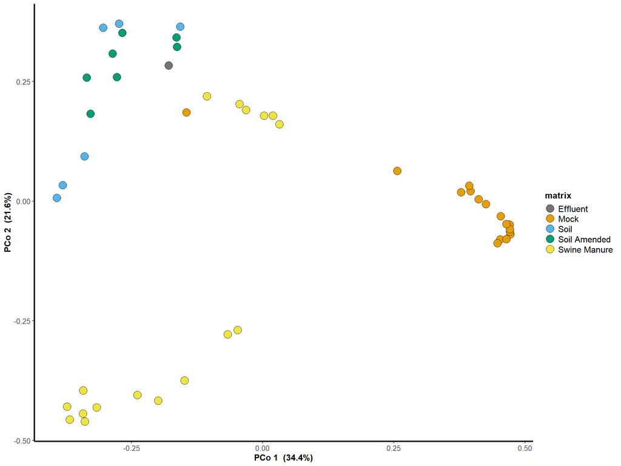

### Normalized PCA

Using relative abundance to normalize samples clusters the replicates tighter, indicating that it works well overall as a normalization method.

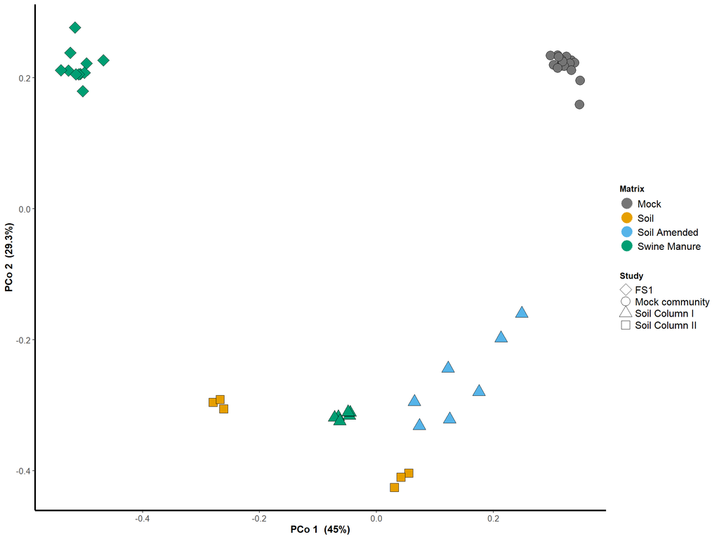

### NMDS

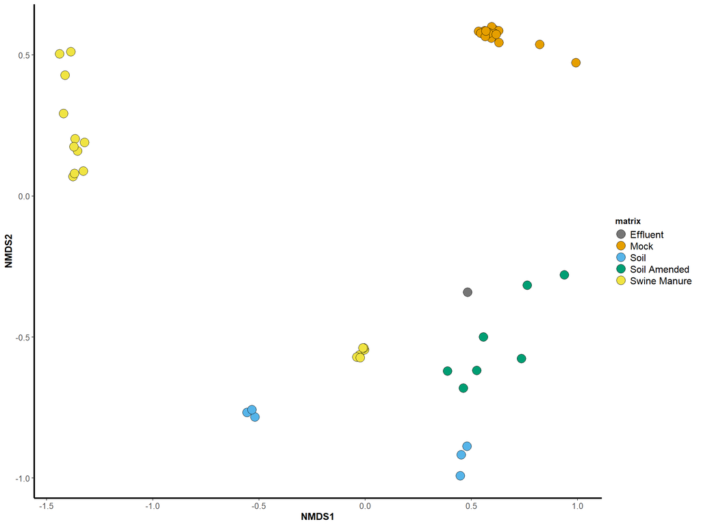

## Hierarchical Clustering

### Bray-Curtis

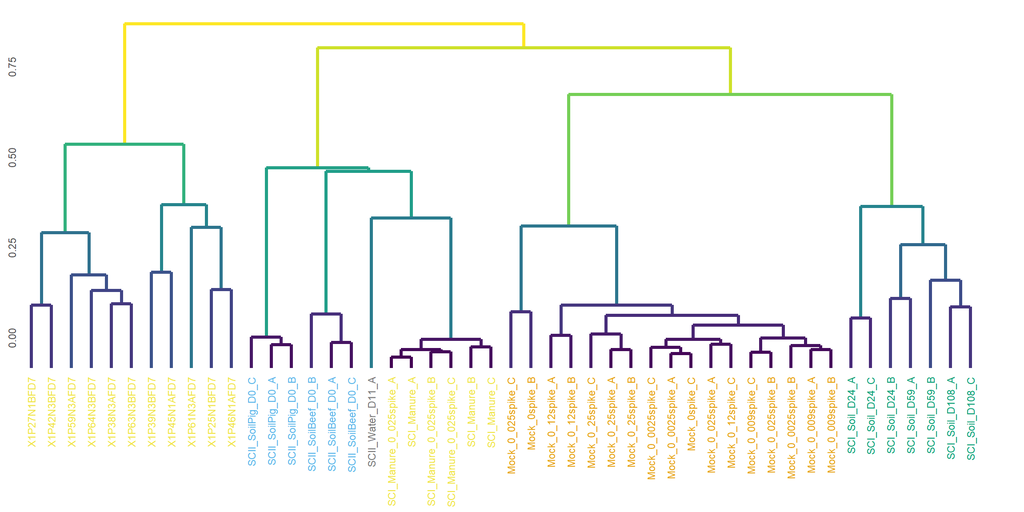

### Jaccard

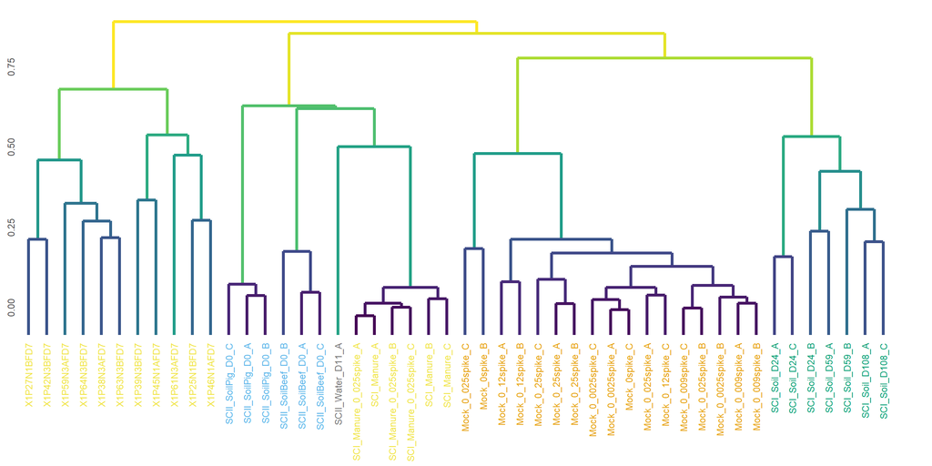

### Euclidean

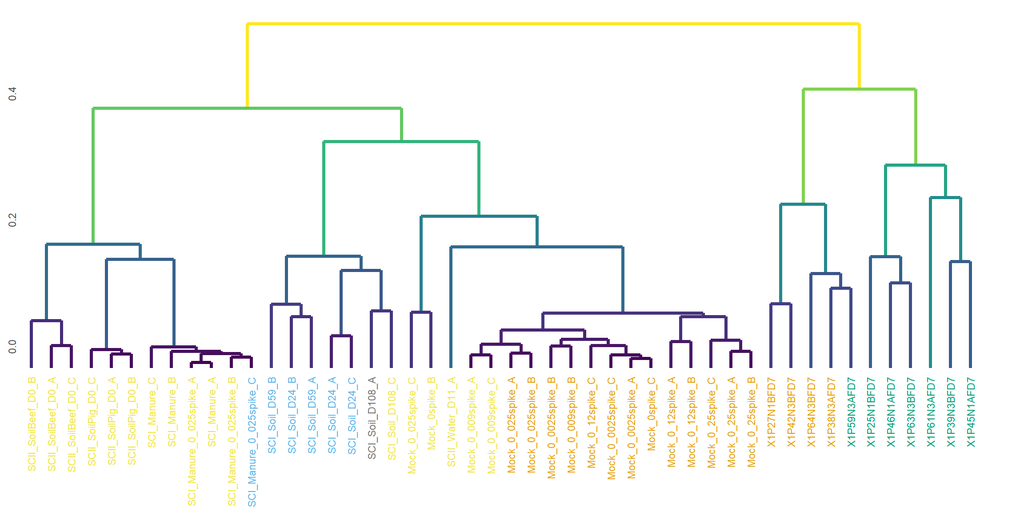

### Gower

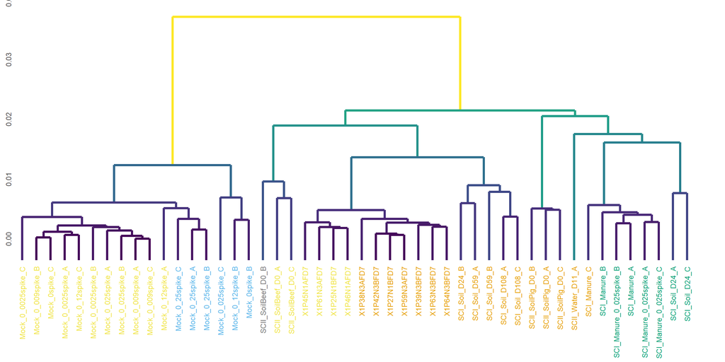

## K-Means Clustering

### Optimize K

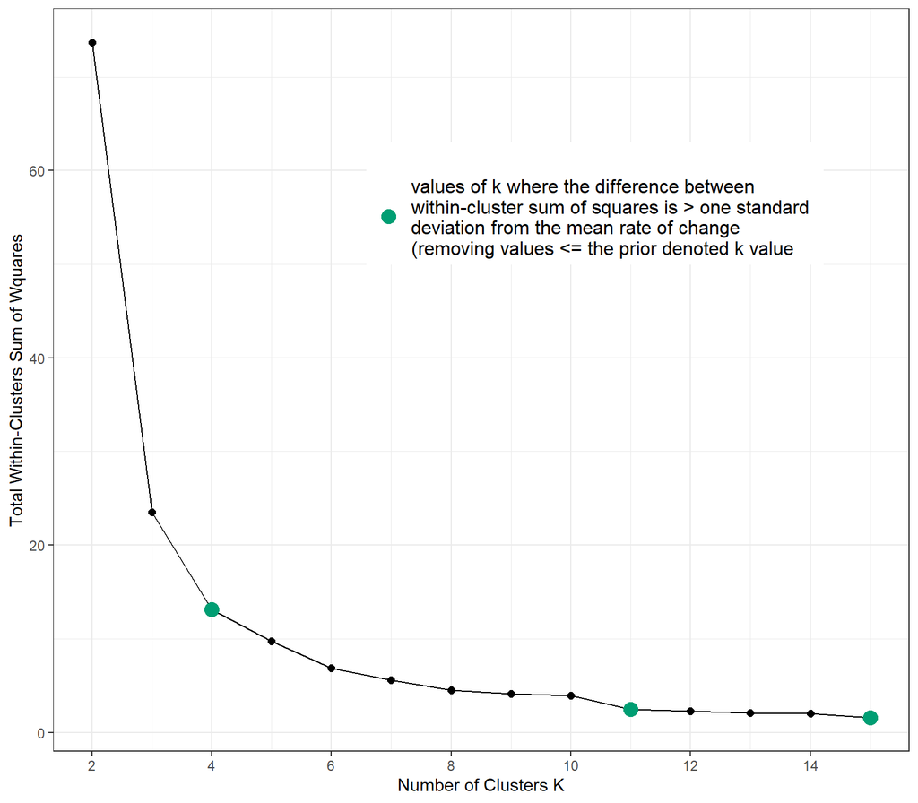

### K(4)

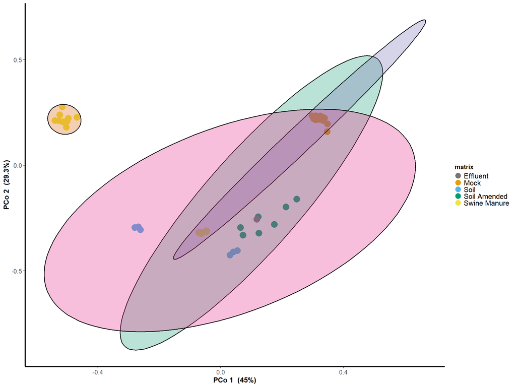

### K(6)

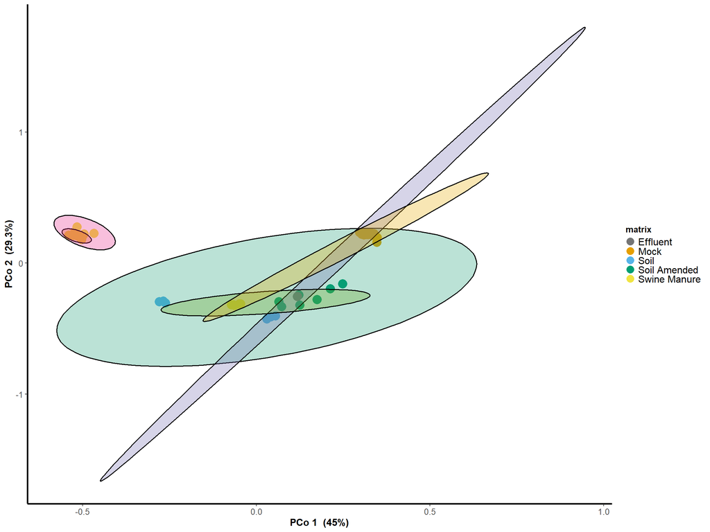

## Sample Compositon

### ARG Profile

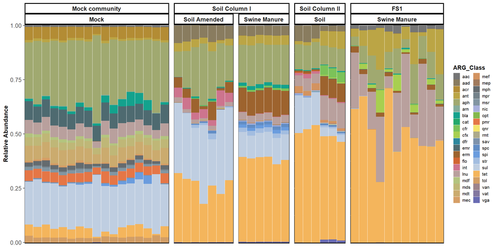

### NGS vs PCR

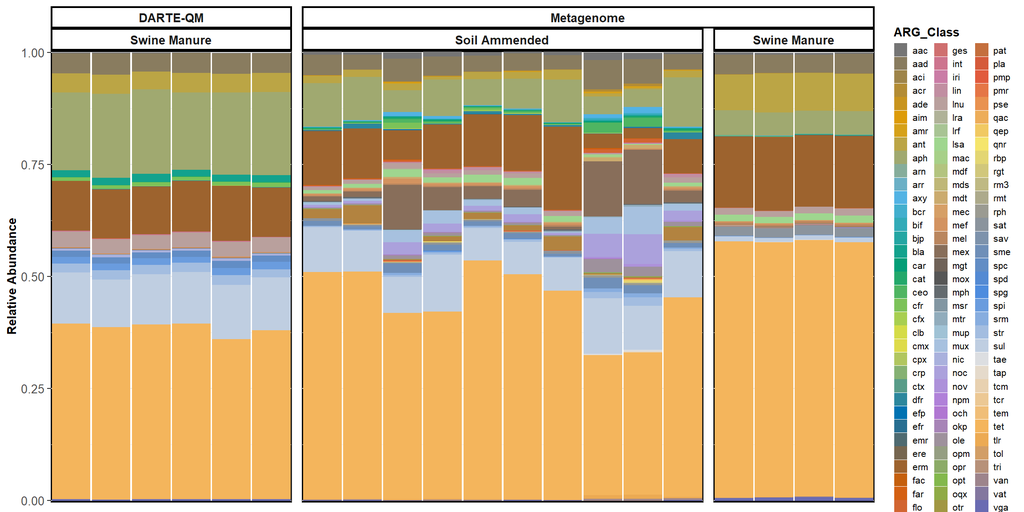

### NGS vs PCR - Targetted Genes

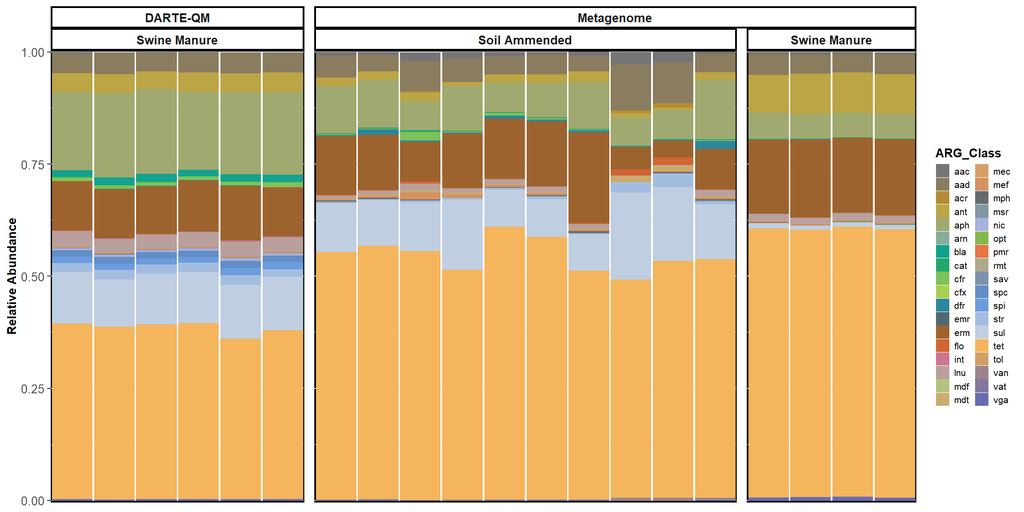